# I See Your True Colors Shining Through

Benjamin Motz

5/5/2020

## Background

The names provided offer a spectacular wealth of information about psychological associations across the color spectrum. For example, are there patterns in the sentiment of color names for different hues? Do people associate different colors with different emotions?

On May 2, 2020, Guy K. from https://colornames.org generously provided a dump of the complete colornames.org database, enhanced with timestamps of when names were proposed and votes were cast, and including geolocation data (inferred from visitor IP addresses using the MaxMind GeoIP2 lookup table). This markdown file documents analyses of these data.

## Initial Import and Preprocessing

We’ll start with some basic cleanup and initiating libraries.

```r
# Clean up
graphics.off()
rm(list=ls())
set.seed(100)
# Libraries
require(tidyverse)  # Keepin' it real
require(fields)     # Creating smooth surfaces
require(reshape2)   # Melting surface matrix back into tidy format
require(lutz)       # Lookup time zone from lat/lon point
require(lubridate)  # Easy date manipulation
require(sentimentr) # Estimate sentiment of text
```

Now let’s download the copy of the raw colornames.org data from OSF:

```r
temp <- tempfile()
download.file("https://osf.io/p25f9/download",temp) # variants - all name proposals
data <- read.csv(temp,header=FALSE,col.names=c("hexcode", "name", "votes", "submit_date", "user_id", "country_iso", "subdivision_iso", "city_name", "postal_code", "latitude", "longitude", "accuracy_radius"),stringsAsFactors=FALSE)
```

Fix things, make things as they should be:

```r
# Remove proposals by the publisher, which were only intended to seed the initiative
data <- data %>% filter(user_id != "d7de10d8a0ee2a852de36b128ef7eaac9a39f6f6")
# Remove errant values (maybe blank proposals?)
data <- data %>% filter(name != "")
# Add RGB and HSV
data <- cbind(data,t(col2rgb(paste("#",data$hexcode,sep = "")))) # RGB
data <- cbind(data,t(rgb2hsv(data$red,data$green,data$blue))) # HSV
# Fix the latitude and longitude
data$latitude <- as.numeric(data$latitude)
data$longitude <- as.numeric(data$longitude)
data$latitude[data$city_name=="Comandante Nicanor Otamendi"] <- -38.1167
data$longitude[data$city_name=="Comandante Nicanor Otamendi"] <- -57.85
# Add timezone to the data
data <- data %>% mutate(tz = tz_lookup_coords(latitude, longitude, method = "fast"))
# Convert submission timestamp strings into timestamps
data$submit_date <- ymd_hms(data$submit_date)
# For those records where we have a time zone, force it on a new date column
local.data <- data %>% filter(!is.na(tz)) %>% rowwise %>%
  mutate(local_submit_date = force_tz(submit_date,tz)) %>%
  select(hexcode,name,votes,user_id,submit_date,local_submit_date)
data <- merge(data, local.data, by=c("hexcode","name","votes","user_id","submit_date"), all.x = TRUE)
# Remove duplicates
data <- data %>% distinct(hexcode,name,votes,user_id,submit_date,local_submit_date, .keep_all = TRUE)
```

## Descriptive Analyses

With the data all imported and preprocessed, we can do some basic summaries of the dataset, just to better-understand what we’re dealing with.

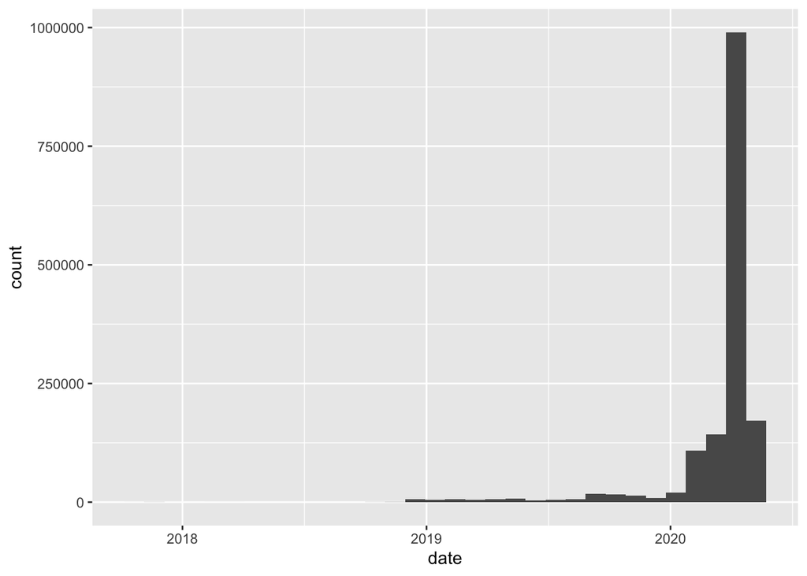

```r
# How many colorname proposals over time?
data %>% mutate(date = as.Date(submit_date,"GMT")) %>%
  ggplot(aes(x=date)) +
  geom_histogram(binwidth=30)
```

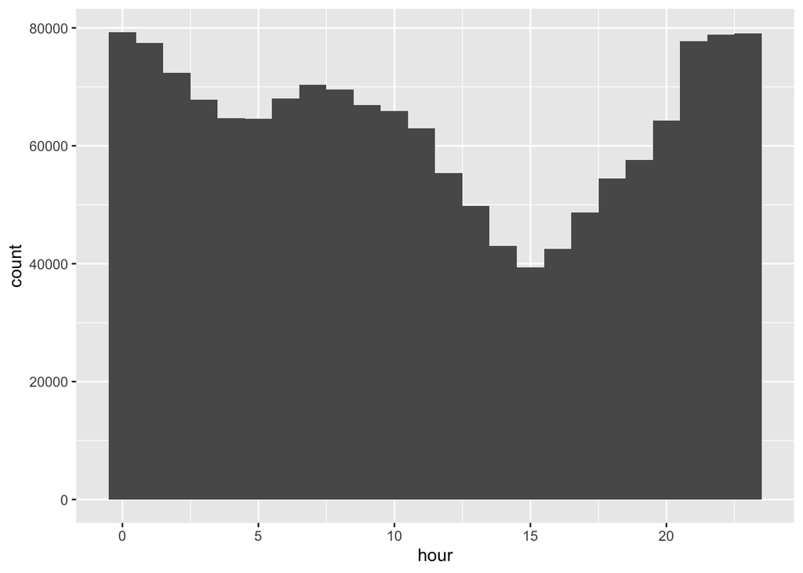

```r
# What time of day did these get submitted?
data %>% filter(!is.na(local_submit_date)) %>% mutate(hour = hour(local_submit_date)) %>%
  ggplot(aes(x=hour)) +
  geom_histogram(binwidth=1)
```

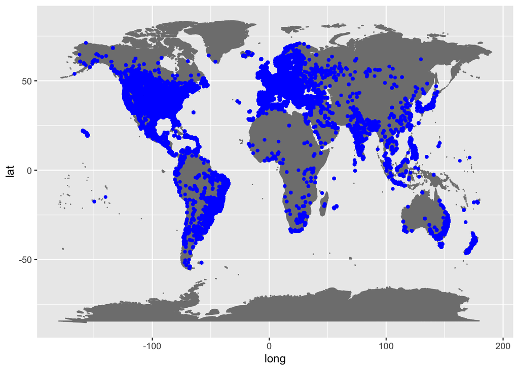

```r
# Where are these proposals coming from?
ggplot() + borders("world", colour="gray50", fill="gray50") +
  geom_point(aes(x=data$longitude,y=data$latitude), color="blue", size=1)
```

## Sentiment

The colornames provided can be estimated for their valence (positive/negative) of sentiment https://en.wikipedia.org/wiki/Sentiment_analysis. There is a well-established body of work examining color preferences across the color spectrum. The sentiment of color names may provide complementary insights into humans’ preferences for different colors.

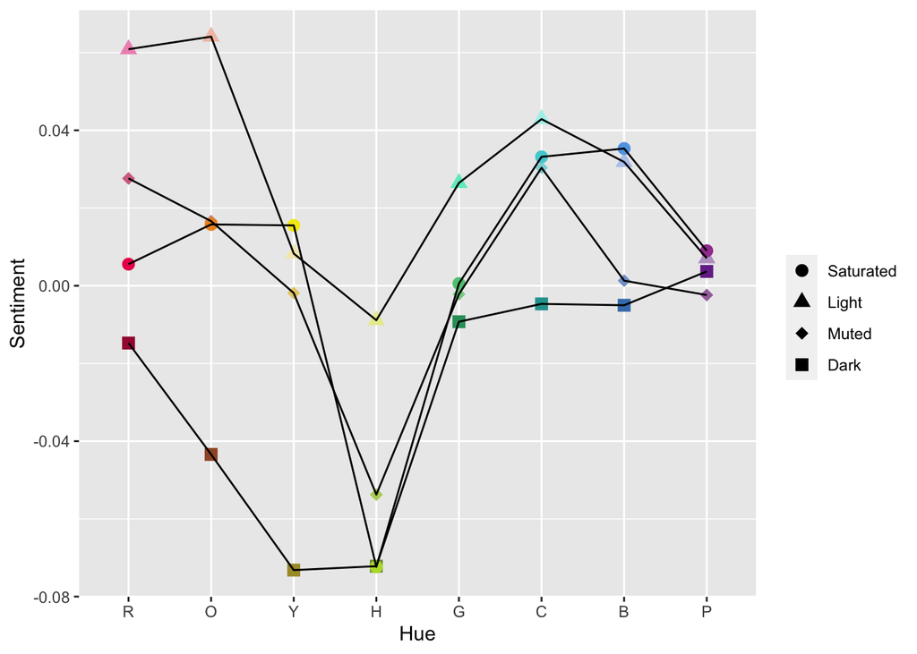

```r
# Get sentiment from sentimentr; this takes a long while
data <- data %>% select(name) %>% get_sentences() %>%
  sentiment_by() %>% select(sentiment = ave_sentiment) %>% bind_cols(data,.)
# Recreate Fig 1C from Palmer & Schloss (2010): 10.1073/pnas.0906172107
# Define the centroid of the 32 colors in the Berkeley Color Project
# "S" is saturated, "L" is light, "M" is muted, "D" is dark
# "R"ed "O"range "Y"ellow c"H"artreuse "G"reen "C"yan "B"lue "P"urple
palmerCats <- data.frame(slice=character(32),hue=character(32),
                         r=numeric(32),g=numeric(32),b=numeric(32),
                         stringsAsFactors = FALSE)
palmerCats[1, ] <- list("Saturated","1",238,0,89)
palmerCats[2, ] <- list("Saturated","2",246,146,36)
palmerCats[3, ] <- list("Saturated","3",255,237,14)
palmerCats[4, ] <- list("Saturated","4",182,218,56)
palmerCats[5, ] <- list("Saturated","5",105,200,133)
palmerCats[6, ] <- list("Saturated","6",96,202,213)
palmerCats[7, ] <- list("Saturated","7",104,164,222)
palmerCats[8, ] <- list("Saturated","8",157,69,159)
palmerCats[9, ] <- list("Light","1",246,145,188)
palmerCats[10,] <- list("Light","2",255,204,168)
palmerCats[11,] <- list("Light","3",255,240,158)
palmerCats[12,] <- list("Light","4",228,238,151)
palmerCats[13,] <- list("Light","5",119,232,200)
palmerCats[14,] <- list("Light","6",167,224,233)
palmerCats[15,] <- list("Light","7",175,198,236)
palmerCats[16,] <- list("Light","8",184,158,201)
palmerCats[17,] <- list("Muted","1",207,115,144)
palmerCats[18,] <- list("Muted","2",211,155,119)
palmerCats[19,] <- list("Muted","3",223,205,116)
palmerCats[20,] <- list("Muted","4",182,207,99)
palmerCats[21,] <- list("Muted","5",134,208,147)
palmerCats[22,] <- list("Muted","6",139,211,214)
palmerCats[23,] <- list("Muted","7",130,160,207)
palmerCats[24,] <- list("Muted","8",164,112,170)
palmerCats[25,] <- list("Dark","1",164,21,68)
palmerCats[26,] <- list("Dark","2",160,89,47)
palmerCats[27,] <- list("Dark","3",161,154,55)
palmerCats[28,] <- list("Dark","4",129,158,68)
palmerCats[29,] <- list("Dark","5",45,158,113)
palmerCats[30,] <- list("Dark","6",42,159,159)
palmerCats[31,] <- list("Dark","7",66,126,187)
palmerCats[32,] <- list("Dark","8",118,48,150)
distThresh <- 30
fdat <- data %>% mutate(sbin=NA,hbin=NA)
for (i in 1:nrow(palmerCats)) { # Cheap way of binning
  fdat$sbin[between(fdat$red, palmerCats$r[i]-distThresh, palmerCats$r[i]+distThresh) &
              between(fdat$green, palmerCats$g[i]-distThresh, palmerCats$g[i]+distThresh) &
              between(fdat$blue, palmerCats$b[i]-distThresh, palmerCats$b[i]+distThresh)] <- palmerCats$slice[i]
  fdat$hbin[between(fdat$red, palmerCats$r[i]-distThresh, palmerCats$r[i]+distThresh) &
              between(fdat$green, palmerCats$g[i]-distThresh, palmerCats$g[i]+distThresh) &
              between(fdat$blue, palmerCats$b[i]-distThresh, palmerCats$b[i]+distThresh)] <- palmerCats$hue[i]
}
cat_data <- fdat %>% filter(!is.na(sbin)) %>% group_by(sbin,hbin) %>%
  summarize(red = mean(red),
            green = mean(green),
            blue = mean(blue),
            sentiment = mean(sentiment))
cat_data$sbin <- factor(cat_data$sbin, levels=c("Saturated","Light","Muted","Dark"))
cat_data$hex <- rgb(round(cat_data$red,0), round(cat_data$green,0), round(cat_data$blue,0), maxColorValue = 255)
ggplot(cat_data,aes(x=hbin,y=sentiment,shape=sbin,group=1)) +
  geom_point(color=cat_data$hex,size=3) +
  scale_shape_manual(values=c(16, 17, 18,15)) +
  geom_path(aes(group=sbin),size=0.5) +
  scale_x_discrete(labels=c("1"="R","2"="O","3"="Y","4"="H","5"="G","6"="C","7"="B","8"="P")) +
  xlab("Hue") + ylab("Sentiment") + labs(shape="")
```

Make the full surface map of all sentiments for all colors…

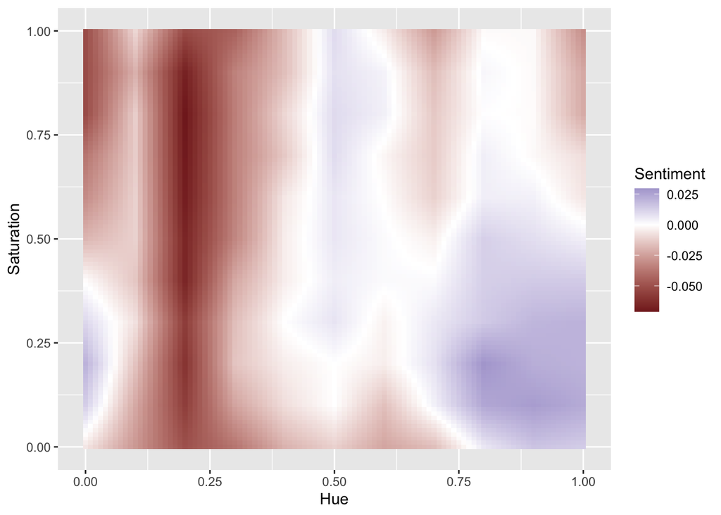

```r
m <- data %>% mutate(hbin=ntile(h,11),
                     sbin=ntile(s,11)) %>%
  group_by(hbin,sbin) %>% summarize(sentiment=mean(sentiment)) %>%
  pivot_wider(names_from = sbin, values_from = sentiment) %>% ungroup() %>% select(-hbin) %>% as.matrix()
obj <- list(x=0:10/10,y=0:10/10,z=m)
surf <- interp.surface.grid(obj=obj,grid.list=list(x=seq(0,1,length=101),
                                                   y=seq(0,1,length=101)))
dimnames(surf$z) <- list(x=surf$x,y=surf$y)
meltedsurf <- melt(surf,value.name="z") %>% na.omit() %>% select(-L1)
ggplot(meltedsurf,aes(x=x,y=y)) +
  geom_tile(aes(fill=z)) +
  scale_fill_gradient2(name="Sentiment") +
  xlab("Hue") + ylab("Saturation")
```

## Semantics of Color

Sentiment is pretty cool, but instead of showing positive and negative sentiment across the color space, wouldn’t it be cool to see how psychological *categories* map onto colors? What parts of the color space are associated with food, with love, with sadness… To classify color names according to categories, we’re going to use pretrained GloVe embeddings from Wikipedia, available at http://nlp.stanford.edu/data/glove.6B.zip. We’ve got a copy on OSF…

```r
temp <- tempfile()
download.file("https://osf.io/e2j3w/download",temp)
g6b <- scan(temp, what="", sep="\n")
vals <- vector(mode = "list", length(g6b))
names <- character(length(g6b))
for (i in 1:length(g6b)) { # this takes a minute or so
  this_vec <- g6b[i]
  this_vec_unlisted <- unlist(strsplit(this_vec, " "))
  this_vec_values <- as.numeric(this_vec_unlisted[-1])
  this_vec_name <- this_vec_unlisted[1]
  vals[[i]] <- this_vec_values
  names[[i]] <- this_vec_name
}
glove <- data.frame(vals)
names(glove) <- names
```

Let’s start by exploring the category “food”. This is actually a pretty diverse category, so rather than just relating a color name to the “food” vector, we’ll compare the tokens in color names to a broad range of food subcategories, and then use the maximum similarity across all subcategories to make a binary decision (yes/no) about whether a colorname is related to “food” or not.

```r
# Categories are from Wikipedia's "List of Foods" page
categories <-     c('legumes','fruit','potatoes','vegetables','mushrooms',
                    'nuts','breads','dairy','butter','cheese','eggs',
                    'meat','cereals','seafood','berries','appetizers',
                    'condiments','confectionery','desserts','dips',
                    'dumplings','halal','kosher','noodles','pies',
                    'salads','sandwiches','sauces','snacks','soups',
                    'stews','cuisine','nutrition','beverages','dishes')
# Make a smaller set of word embeddings
glovecategories <- glove[,which( colnames(glove) %in% categories )]

# For this analysis we're going to take a subset of the colornames
# for the sake of efficiency
sdat <- data[sample(nrow(data),200000),]

# Initialize an output file
output <- data.frame(name = sdat$name,
                     hexcode = sdat$hexcode,
                     simcat = character(length(sdat$name)),
                     simscore = numeric(length(sdat$name)),
                     stringsAsFactors = FALSE)
for (i in 1:length(sdat$name)) {
  maxcat <- "none"
  maxsim <- 0
  this.name <- sdat$name[i] %>% tolower() %>%
    str_replace_all("[^[:alpha:]]", " ") %>%
    str_replace_all("\\s+", " ") %>%
    str_replace_all("red","") %>% str_replace_all("orange","") %>% str_replace_all("yellow","") %>%
    str_replace_all("green","") %>% str_replace_all("blue","") %>% str_replace_all("brown","") %>%
    str_replace_all("purple","") %>% str_replace_all("violet","") %>% str_replace_all("pink","")
  source.words <- strsplit(this.name," ")[[1]]
  for (j in 1:length(source.words)) {
    try({
      source.vector <- glove[[source.words[j]]]
      for (cat in categories) {
        target.vector <- glovecategories[[cat]]
        dot_product <- source.vector %*% target.vector
        norm_prod <- sqrt(sum(source.vector**2)) * sqrt(sum(target.vector**2))
        similarity <- as.numeric(dot_product/norm_prod)
        if (similarity > maxsim) {
          maxcat <- cat
          maxsim <- similarity
        }
      }
    },silent=TRUE)
  }
  output$simcat[i] <- maxcat
  output$simscore[i] <- maxsim
  if(i %% 1000 == 0) {print(paste(i,": ",sdat$name[i],":",maxcat,",",maxsim))}
}
```

```
## [1] "1000 :  Neon Roses Pink : fruit , 0.458267391414903"
## [1] "2000 :  Heras Grief : nutrition , 0.202422053287597"
## [1] "3000 :  Blank : nuts , 0.114480238320873"
## [1] "4000 :  Tweenage Schoolbag : confectionery , 0.0772162754455868"
## [1] "5000 :  Pendejos Forces : eggs , 0.106928162015215"
## [1] "6000 :  Barbie Dream World : pies , 0.380624281538261"
## [1] "7000 :  Springtime Leafs : berries , 0.38394188329314"
## [1] "8000 :  Tubbataha Reef : seafood , 0.326807926637889"
## [1] "9000 :  Screen : dishes , 0.320244367470359"
## [1] "10000 :  Margo : legumes , 0.184725288478038"
## [1] "11000 :  Plump : berries , 0.51495771037875"
## [1] "12000 :  Moody Rose Red : dips , 0.397750133068736"
## [1] "13000 :  Summer Rose Of Plenty : dips , 0.397750133068736"
## [1] "14000 :  The Sky Is Blue 3 : fruit , 0.354102974844089"
## [1] "15000 :  Fiery LED : fruit , 0.191190816439524"
```

[output cut: 185 more lines]

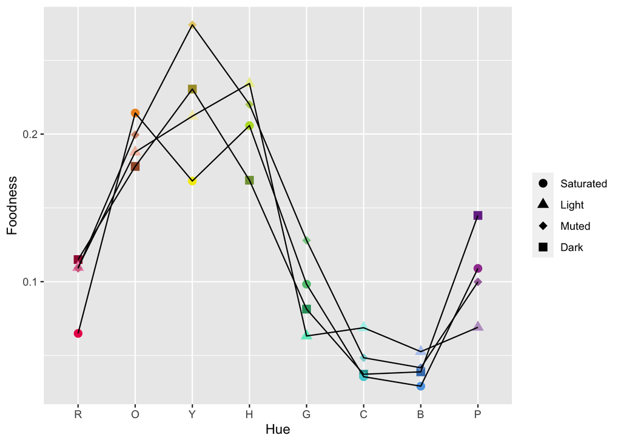

```r
# Combine back with color values
sdat <- merge(sdat,output,by=c("name","hexcode"))
# Decide whether it's a food (>0.6)
sdat <- sdat %>% mutate(simbin = if_else(simscore < 0.6, 0, 1))
## Let's try the Palmer & Schloss plot again
fdat <- sdat %>% mutate(sbin=NA,hbin=NA)
for (i in 1:nrow(palmerCats)) { # Cheap way of binning
  fdat$sbin[between(fdat$red, palmerCats$r[i]-distThresh, palmerCats$r[i]+distThresh) &
              between(fdat$green, palmerCats$g[i]-distThresh, palmerCats$g[i]+distThresh) &
              between(fdat$blue, palmerCats$b[i]-distThresh, palmerCats$b[i]+distThresh)] <- palmerCats$slice[i]
  fdat$hbin[between(fdat$red, palmerCats$r[i]-distThresh, palmerCats$r[i]+distThresh) &
              between(fdat$green, palmerCats$g[i]-distThresh, palmerCats$g[i]+distThresh) &
              between(fdat$blue, palmerCats$b[i]-distThresh, palmerCats$b[i]+distThresh)] <- palmerCats$hue[i]
}
cat_data <- fdat %>% filter(!is.na(sbin)) %>% group_by(sbin,hbin) %>%
  summarize(red = mean(red),
            green = mean(green),
            blue = mean(blue),
            foodness = mean(simbin))
cat_data$sbin <- factor(cat_data$sbin, levels=c("Saturated","Light","Muted","Dark"))
cat_data$hex <- rgb(round(cat_data$red,0), round(cat_data$green,0), round(cat_data$blue,0), maxColorValue = 255)
ggplot(cat_data,aes(x=hbin,y=foodness,shape=sbin,group=1)) +
  geom_point(color=cat_data$hex,size=3) +
  scale_shape_manual(values=c(16, 17, 18,15)) +
  geom_path(aes(group=sbin),size=0.5) +
  scale_x_discrete(labels=c("1"="R","2"="O","3"="Y","4"="H","5"="G","6"="C","7"="B","8"="P")) +
  xlab("Hue") + ylab("Foodness") + labs(shape="")
```

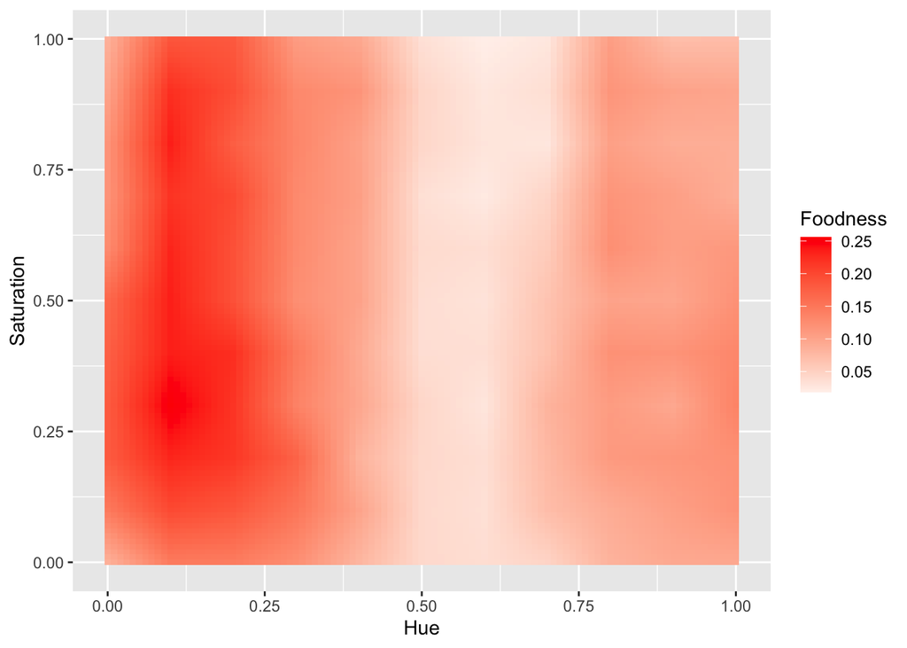

```r
## Plot the surface
m <- sdat %>% mutate(hbin=ntile(h,11),
                     sbin=ntile(s,11)) %>%
  group_by(hbin,sbin) %>% summarize(foodness=mean(simbin)) %>%
  pivot_wider(names_from = sbin, values_from = foodness) %>% ungroup() %>% select(-hbin) %>% as.matrix()
obj <- list(x=0:10/10,y=0:10/10,z=m)
surf <- interp.surface.grid(obj=obj,grid.list=list(x=seq(0,1,length=101),
                                                   y=seq(0,1,length=101)))
dimnames(surf$z) <- list(x=surf$x,y=surf$y)
meltedsurf <- melt(surf,value.name="z") %>% na.omit() %>% select(-L1)
ggplot(meltedsurf,aes(x=x,y=y,z=z,fill=z)) +
  geom_tile() +
  scale_fill_gradient2(name="Foodness", low = "white", high = "red") +
  xlab("Hue") + ylab("Saturation")
```